# Programowanie w R: Projekt

Celem projektu jest określenie jakie mogą być główne przyczyny stopniowego karłowacenia śledzi oceanicznych wyławianych w Europie.

## Opis danych

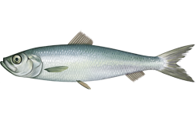

Na przestrzeni ostatnich lat zauważono stopniowy spadek rozmiaru śledzia oceanicznego wyławianego w Europie. Do analizy zebrano pomiary śledzi i warunków w jakich żyją z ostatnich 60 lat. Dane były pobierane z połowów komercyjnych jednostek. W ramach połowu jednej jednostki losowo wybierano od 50 do 100 sztuk trzyletnich śledzi. Dane są dostępne na [stronie przedmiotu](https://ekursy.put.poznan.pl/course/view.php?id=14619).

Kolejne kolumny w zbiorze danych to:

- **length**: długość złowionego śledzia [cm];
- **cfin1**: dostępność planktonu [zagęszczenie *Calanus finmarchicus* gat. 1];
- **cfin2**: dostępność planktonu [zagęszczenie *Calanus finmarchicus* gat. 2];
- **chel1**: dostępność planktonu [zagęszczenie *Calanus helgolandicus* gat. 1];
- **chel2**: dostępność planktonu [zagęszczenie *Calanus helgolandicus* gat. 2];
- **lcop1**: dostępność planktonu [zagęszczenie widłonogów gat. 1];
- **lcop2**: dostępność planktonu [zagęszczenie widłonogów gat. 2];
- **fbar**: natężenie połowów w regionie [ułamek pozostawionego narybku];
- **recr**: roczny narybek [liczba śledzi];
- **cumf**: łączne roczne natężenie połowów w regionie [ułamek pozostawionego narybku];
- **totaln**: łączna liczba ryb złowionych w ramach połowu [liczba śledzi];
- **sst**: temperatura przy powierzchni wody [°C];
- **sal**: poziom zasolenia wody [Knudsen ppt];
- **xmonth**: miesiąc połowu [numer miesiąca];
- **nao**: oscylacja północnoatlantycka [mb].

## Wymagania

Raport z analizy danych powinien być napisany z wykorzystaniem języka **RMarkdown** i paczki **knitr**. Źródła i pliki wynikowe powinny zostać udostępnione w ramach konta **GitHub** studenta. Oprócz pliku źródłowego (**.Rmd**) w repozytorium, należy również upublicznić raport w wersji html na stronie **github.io** powiązanej z projektem. Na [stronie przedmiotu](https://ekursy.put.poznan.pl/course/view.php?id=14619) znajduje się formularz do wgrania raportu w formacie html oraz do podania adresu repozytorium.

Na początku pliku powinna znajdować się automatycznie wypełniona **data generacji dokumentu** oraz **spis treści** pozwalający przejść do najważniejszych sekcji. Ponadto **raport powinien zaczynać się od rozdziału podsumowującego całą analizę**, streszczającego najważniejsze spostrzeżenia analityka (ang. *executive summary*). Należy tu podkreślić, że właśnie zrozumienie danych, czytelna prezentacja wyników oraz stosowanie się do podstawowych zasad wizualizacji danych będą, obok technicznej strony raportu, podstawą do oceny. Po wstępie, raport powinien zawierać m.in. następujące elementy:

1. Kod wyliczający wykorzystane biblioteki.
2. Kod zapewniający powtarzalność wyników przy każdym uruchomieniu raportu na tych samych danych.
3. Kod pozwalający wczytać dane z pliku.
4. Kod przetwarzający brakujące dane.
5. Sekcję podsumowującą rozmiar zbioru i podstawowe statystyki.
6. Szczegółową analizę wartości atrybutów (np. poprzez prezentację rozkładów wartości).
7. Sekcję sprawdzającą korelacje między zmiennymi; sekcja ta powinna zawierać jakąś formę graficznej prezentacji korelacji.
8. Interaktywny wykres lub animację, np. prezentującą zmianę rozmiaru śledzi w czasie.
9. Sekcję próbującą stworzyć regresor przewidujący rozmiar śledzia (w tej sekcji należy wykorzystać wiedzę z pozostałych punktów oraz wykonać dodatkowe czynności, które mogą poprawić trafność predykcji); dobór parametrów modelu oraz oszacowanie jego skuteczności powinny zostać wykonane za pomocą techniki podziału zbioru na dane uczące, walidujące i testowe; trafność regresji powinna zostać oszacowana na podstawie miar $R^2$ i $RMSE$.
10. Analizę ważności atrybutów najlepszego znalezionego modelu regresji. Analiza ważności atrybutów powinna stanowić próbę odpowiedzi na pytanie: co sprawia, że rozmiar śledzi zaczął w pewnym momencie maleć.

Jeśli analityk uzna to za stosowne, powyższe punkty mogę być wykonane w innej kolejności. **Analityk nie musi, a nawet nie powinien, ograniczać się do powyższych punktów.** Wszelkie dodatkowe techniki analizy danych, wizualizacje, spostrzeżenia będą pozytywnie wpływały na ocenę. Jeśli analityk uzna to za stosowne, może rozszerzyć zbiór danych o dodatkowe, ogólnodostępne, informacje. Ewentualne konkluzje, znalezione zależności warto potwierdzić dokonując sprawdzenia istniejących wyników badań w literaturze naukowej (np. na [Google Scholar](https://scholar.google.pl/)).

### Termin oddania projektu: 03.12.2022